# GPU-accelerated single-cell and spatial transcriptomics on NVIDIA DGX H100

A systematic benchmark of speed, scalability, and biological concordance

Luca Vedovelli, Corrado Lanera, Daniele Sabbatini, Dario Gregori

University of Padova · Pediatric Research Institute «Città della Speranza»

2/09/2026

## The scale problem

- Single-cell RNA-seq datasets now routinely exceed **1 million cells**
- Spatial platforms (Visium HD) produce **hundreds of thousands of bins** per section
- The standard tools (**Scanpy**, **Squidpy**) are **CPU-bound**
- A full atlas-scale analysis can take **hours to days**

### The question

> Can GPUs make atlas-scale single-cell analysis routine — **without changing the biology**?

## What we benchmarked

**Hardware**

- NVIDIA **DGX H100** node: 8× H100 80 GB, 112 cores, 2 TB RAM
- Spatial: local **RTX 4090** workstation

**Software**

- CPU: **Scanpy 1.12** (100 threads)
- GPU: **rapids-singlecell 0.14.1** (RAPIDS / CuPy / cuGraph)
- Reproducible **Singularity** containers

**Five questions**

1. Per-step & end-to-end **speedup**
2. **Multi-GPU** scaling (1→8 H100)
3. Biological **concordance** (CPU vs GPU)
4. **Maximum capacity** on one node
5. Generalisation to **spatial** transcriptomics

## The pipeline is identical on both sides

- Same dataset: **10x 1.3M mouse brain cells**, subsampled to 10k / 50k / 100k / 500k / 1.3M
- Same parameters: QC → normalise → **2,000 HVGs** → PCA (50) → kNN (k=15) → **Leiden** → UMAP → **Wilcoxon DE**
- Same seed (42), **five independent repeats** per configuration
- Concordance measured directly: HVG Jaccard, PCA correlation, ARI/NMI, DE log-fold-change

## Up to 120× faster end-to-end

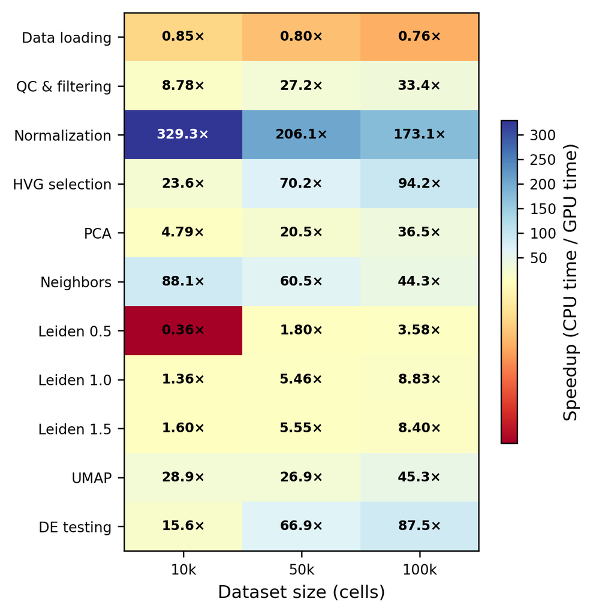

## Where the time goes

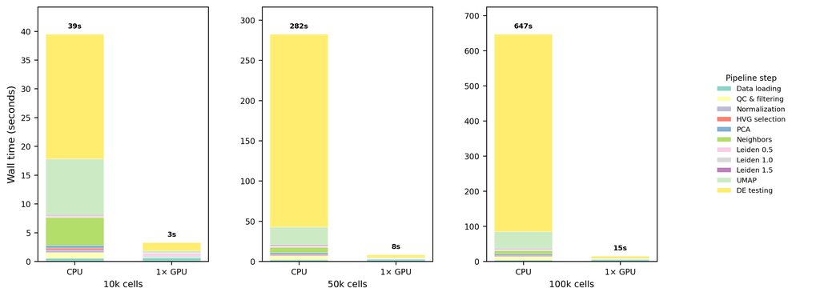

## More GPUs help less than you’d hope

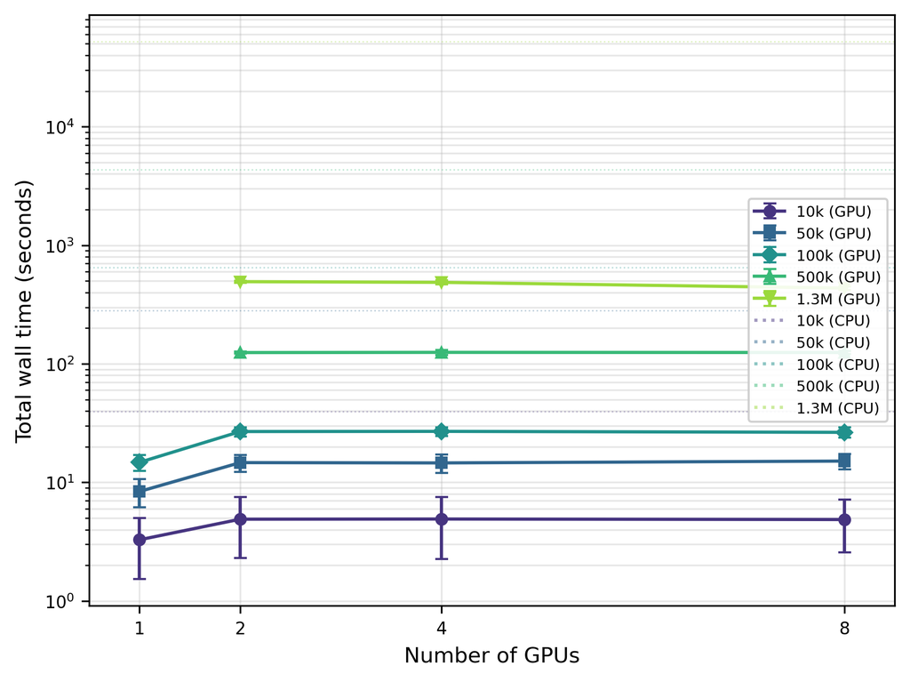

Total time vs number of GPUs. Curves are nearly flat beyond 2 GPUs.

- 8 GPUs only **12% faster** than 2 GPUs at 1.3M cells
- In an 8-GPU run: **75%** of wall time is CPU preprocessing
- Only **4%** runs on multiple GPUs
- Classic **Amdahl’s law**

## So use the node differently

**Practical takeaway**

A DGX node is better used as **eight independent single-GPU workers** running eight analyses in parallel — than as one 8-GPU worker on a single analysis.

- Most of the value is on **one** GPU
- A single cloud-rented H100 (**~$2–4/hour**) captures nearly all the benefit
- GPU acceleration is **accessible**, not just for those with a DGX

## The biology is preserved

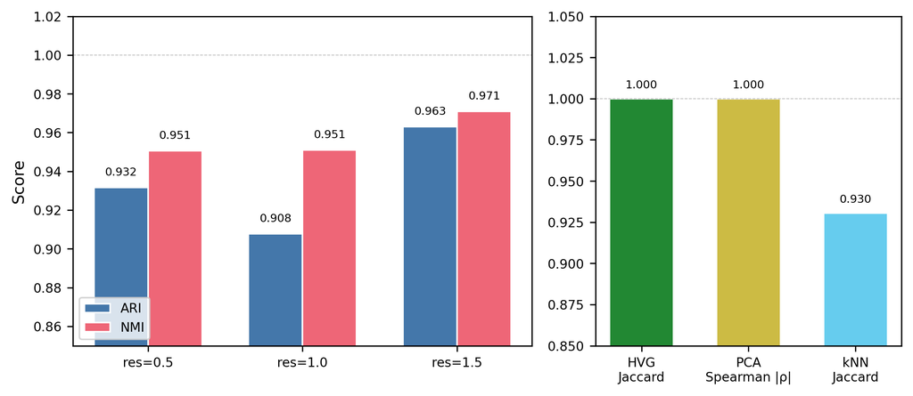

CPU–GPU concordance on 10k cells: clustering ARI/NMI and feature-level agreement.

- HVG selection **identical** (Jaccard = 1.0)
- PCA loadings **perfectly correlated** (|ρ| = 1.0)
- Leiden **ARI 0.908–0.963**, NMI 0.951–0.971
- DE log-fold-change **ρ = 0.946**

**Speed without changing conclusions.**

## How far can one node go?

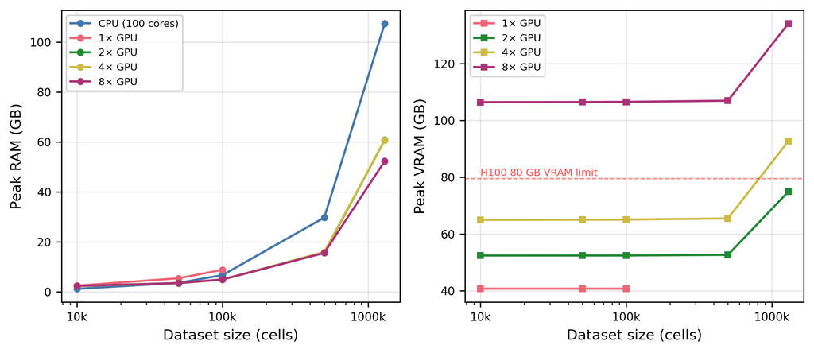

## Differential expression: pseudo-bulk wins twice

| Method | Time @ 3.4M cells | Note |
| --- | --- | --- |
| CPU t-test (cell-level) | 5,598 s | baseline |
| GPU Wilcoxon | 826 s |  |
| **Pseudo-bulk aggregation** | **128 s** | **44× faster** |

- Pseudo-bulk is the **fastest** *and* the most **statistically rigorous** (avoids pseudoreplication)
- Fast and correct are not in tension here

## It generalises to spatial transcriptomics

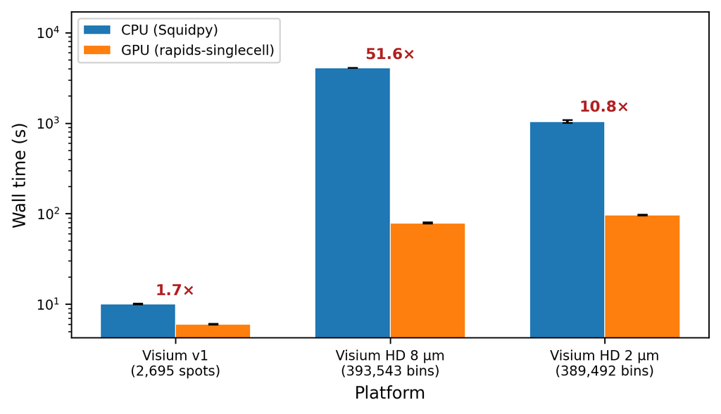

- Up to **51.6×** end-to-end (Visium HD 8 µm)
- Co-occurrence analysis: **3,272×**
- Spatial autocorrelation concordance **ρ ≥ 0.9995**
- On a **single consumer RTX 4090**

## Takeaways

1. **120× faster** end-to-end, with **biologically concordant** results
2. Bottleneck is **CPU preprocessing**, not GPU compute — so most value is on **one GPU**
3. Scaling limit is **CPU RAM**, not VRAM (11.9M cells on one node)
4. **Pseudo-bulk DE** is fastest *and* most rigorous
5. Generalises to **spatial** (51.6×) — even on consumer hardware

**Note**

Code, containers, and all benchmark data: **github.com/lucavd/2026.scRNA_DGX**

## Thank you

**Luca Vedovelli** · luca.vedovelli@ubep.unipd.it

Unit of Biostatistics, Epidemiology and Public Health — University of Padova BIOSTAT-X — Pediatric Research Institute «Città della Speranza»

*Acknowledgements: UPSCALE / CONVECS HPC, University of Padova (DGX H100).* *Funded by PNC “DARE” (PNC0000002) and BIRD 2024/START (SID) programs.*